# Stigmatizing Language Bootstrap

2022-09-20

# 1 Data

## 1.1 Preview

Here is a preview of the dataset.

| bootstrap | shuffle | class | target_word | african_american | caucasian | hispanic | subclass |
| --- | --- | --- | --- | --- | --- | --- | --- |
| 0 | 0 | stigmatizing | nonadherent | 1.0280947 | 1.0301015 | 1.1090419 | passivity |
| 0 | 0 | stigmatizing | anger | 0.9852738 | 0.8237815 | 0.9021186 | violence |
| 0 | 0 | stigmatizing | combative | 0.9175508 | 0.8505373 | 1.0002095 | violence |
| 0 | 0 | stigmatizing | defensiveness | 0.9964036 | 0.9354759 | 1.0425980 | violence |
| 0 | 0 | stigmatizing | agitation | 0.9322864 | 0.8684692 | 0.9755630 | violence |
| 0 | 0 | stigmatizing | agitated | 0.9267627 | 0.8540608 | 0.9987062 | violence |
| 0 | 0 | stigmatizing | challenges | 0.9956563 | 0.8861797 | 0.9637392 | passivity |
| 0 | 0 | stigmatizing | noncooperative | 0.9173977 | 0.8726118 | 0.8822080 | passivity |
| 0 | 0 | stigmatizing | defensive | 0.9912665 | 1.0093859 | 0.9868874 | violence |
| 0 | 0 | stigmatizing | confronting | 0.9524879 | 0.9622938 | 0.8693942 | violence |
| 0 | 0 | stigmatizing | resists | 0.9284718 | 0.9537971 | 1.0259848 | passivity |
| 0 | 0 | stigmatizing | agitate | 0.9245118 | 0.9135065 | 1.0540184 | violence |
| 0 | 0 | stigmatizing | confront | 0.9324438 | 0.8983797 | 1.0844225 | violence |
| 0 | 0 | stigmatizing | confronted | 0.9700138 | 0.9186482 | 1.0038392 | violence |
| 0 | 0 | stigmatizing | combativeness | 0.9571400 | 0.8606996 | 0.9933709 | violence |
| 0 | 0 | stigmatizing | angry | 1.0165817 | 0.8917338 | 0.9984798 | violence |
| 0 | 0 | stigmatizing | challenging | 1.0247580 | 1.0238746 | 0.9760860 | passivity |
| 0 | 0 | stigmatizing | angrily | 0.8552293 | 0.7869885 | 0.9537982 | violence |
| 0 | 0 | stigmatizing | resisting | 1.0121662 | 0.8809934 | 1.0238783 | passivity |
| 0 | 0 | stigmatizing | aggressiveness | 1.0470417 | 1.0003917 | 1.0964945 | violence |
| 0 | 0 | stigmatizing | aggression | 0.9677948 | 0.8479988 | 0.9505767 | violence |
| 0 | 0 | stigmatizing | resist | 1.1262788 | 0.9453620 | 1.0639894 | passivity |
| 0 | 0 | stigmatizing | resisted | 1.0457037 | 0.9652100 | 1.0370602 | passivity |
| 0 | 0 | stigmatizing | non_compliant | 0.9709175 | 0.9631800 | 1.0433823 | passivity |
| 0 | 0 | stigmatizing | confrontation | 0.9903648 | 0.9668809 | 1.0726310 | violence |
| 0 | 0 | stigmatizing | noncompliant | 0.9234636 | 0.9245073 | 1.0027731 | passivity |
| 0 | 0 | stigmatizing | aggressively | 1.0681528 | 1.0517648 | 1.0405816 | violence |
| 0 | 0 | stigmatizing | resistance | 1.0118977 | 0.9248097 | 1.0086146 | passivity |
| 0 | 0 | stigmatizing | unpleasant | 0.9859867 | 0.9751963 | 0.9543081 | passivity |
| 0 | 0 | stigmatizing | noncompliance | 0.9849267 | 0.9388849 | 0.9802925 | passivity |

[output cut: 70 more lines]

## 1.2 Stigmatizing Words

There are 39 distinct target words in our dataset. Some of them are synonyms.

```r
boot_data %>%
  select(class, subclass, target_word) %>%
  distinct() %>%
  arrange(target_word) %>%

  kable() %>%
  kable_styling('striped') %>%
  scroll_box(height='200px')
```

| class | subclass | target_word |
| --- | --- | --- |
| stigmatizing | violence | aggression |
| stigmatizing | violence | aggressive |
| stigmatizing | violence | aggressively |
| stigmatizing | violence | aggressiveness |
| stigmatizing | violence | agitate |
| stigmatizing | violence | agitated |
| stigmatizing | violence | agitation |
| stigmatizing | violence | anger |
| stigmatizing | violence | angrily |
| stigmatizing | violence | angry |
| stigmatizing | passivity | challenged |
| stigmatizing | passivity | challenges |
| stigmatizing | passivity | challenging |
| stigmatizing | violence | combative |
| stigmatizing | violence | combativeness |
| stigmatizing | violence | confront |
| stigmatizing | violence | confrontation |
| stigmatizing | violence | confrontational |
| stigmatizing | violence | confronted |
| stigmatizing | violence | confronting |
| stigmatizing | violence | defensive |
| stigmatizing | violence | defensiveness |
| stigmatizing | passivity | non_adherence |
| stigmatizing | passivity | non_adherent |
| stigmatizing | passivity | non_compliance |
| stigmatizing | passivity | non_compliant |
| stigmatizing | passivity | nonadherence |
| stigmatizing | passivity | nonadherent |
| stigmatizing | passivity | noncompliance |
| stigmatizing | passivity | noncompliant |
| stigmatizing | passivity | noncooperative |
| stigmatizing | passivity | resist |
| stigmatizing | passivity | resistance |
| stigmatizing | passivity | resistances |
| stigmatizing | passivity | resistant |
| stigmatizing | passivity | resisted |
| stigmatizing | passivity | resisting |
| stigmatizing | passivity | resists |
| stigmatizing | passivity | unpleasant |

## 1.3 Counts

# 2 Bootstrap Process

1. Create $m$ bootstrap datasets $D_{m=1, 2, ..., z}$ by randomly sampling patients from the original 40,000 UCSF patients’ notes dataset. By resampling with replacement on patients, we are being explicit about the correlation structure of notes written for a single patient.
2. From those $m$ bootstrap datasets, consider the plug-in estimator $\hat{\theta}_m=f(D_m)$ for a quantity of interest $\theta$. Calculate $\hat{\theta}_m$ for each bootstrap dataset $D_m$.
3. Calculate the mean $\bar{x}(\hat{\theta}_m)$ and standard deviation $s(\hat{\theta}_m)$.
4. The $(1-\alpha)\times 100$% confidence interval for $\theta$ can be constructed using

$$\bar{x}(\hat{\theta}_m) \pm \Phi(1-\alpha) \times s(\hat{\theta}_m)$$
where $\Phi$ is the normal distribution CDF.

# 3 Statistics

We can consider several quantities as $\theta$ depending on our research question.

## 3.1 Single Base-Target Pairs

If we would like to understand whether or not there is evidence for a base-target pair to be synonymous and antonymous, we consider these hypotheses and

$$H_0: \mu_\text{Base, Target} = 1
\\
H_1: \mu_\text{Base, Target} \neq 1$$

want to use the bootstrap statistic

$$\hat{\theta}_m = \frac{1}{k} \sum_{k} \text{cos-dis}(\text{Base,
Target})_k$$
where $k$ represents the index of a cosine distance/data shuffle within a bootstrap dataset. (Each shuffle corresponds to an estimated cosine distance between a base and target.)

## 3.2 Two Bases and Single Target

Should we wish to understand if two bases have equal cosine distances from the same single target, then we need to consider another bootstrap statistic.

$$H_0: \mu_\text{Base 1, Target} = \mu_\text{Base 2, Target}
\\
H_1: \mu_\text{Base 1, Target} \neq \mu_\text{Base 2, Target}$$
We will opt to study the mean difference of cosine distances. We will calculate the statistic

$$\hat{\theta_m} = \frac{1}{k} \sum_{k} \text{cos-dis}(\text{Base 1,
Target})_k - \text{cos-dis}(\text{Base 2, Target})_k$$
for each of the $m$ bootstraps. Then, we can test whether or not this difference is 0 or not.

## 3.3 Three Bases and Single Target

If we are interested in testing

$$H_0: \mu_\text{Base 1, Target} = \mu_\text{Base 2, Target} =
\mu_\text{Base 3, Target}
\\
H_1: \text{At least one } \mu_\text{Base, Target} \text{ does not equal
the others.}$$
we can consider using the same bootstrap statistic for each of the possible pairs $P = [ \{1,2\}, \{1,3\}, \{2,3\} ]$:

$$\hat{\theta_m} = \frac{1}{k} \sum_{k} \text{cos-dis}(\text{Base 1,
Target})_k - \text{cos-dis}(\text{Base 2, Target})_k$$

then correct the confidence intervals using Bonferroni significance level $\frac{\alpha}{\text{Number of Bases}}$ to control for family-wise error rate.

### 3.3.1 Bonferroni

We will correct the confidence intervals we create for each base word using Bonferroni’s correction.

$$\text{p-value}_\text{Bonferonni} = \frac{\text{1-Confidence
Level}}{\text{Number of Tests}}$$
If we are creating (1-$\alpha$) % CI’s, then we will be considering this p-value.

$$\text{p-value}_\text{Bonferonni} = \frac{1-0.95}{3} \approx 0.0167$$

We can get the normal quantile to create our confidence intervals.

$$\Phi(0.0167) \approx 2.13$$

## 3.4 Three Bases and Synonymous/Class Targets

In order to combine synonymous targets or targets within a class, we propose a bootstrap statistic that uses inverse-variance weighting or precision weighting. Using the $m^{th}$ bootstrap dataset, for each ethnic base term, calculate

$$\text{Precision-Weighted Average (PWA)} = \sum_k \frac{a_1\text{[Average
Cosine Distance]}_1 + ... + a_k\text{[Average Cosine Distance]}_k}{a_1 +
... + a_k}$$
where $a_k = \text{var}(\text{Average Cosine Distance})^{-1}$. This is a weighted average of the mean cosine distances of each of the synonymous/class targets. We are essentially weighting the cosine distances between bases/targets by how variable they are.

To review, we will have 3 precision weighted averages per bootstrap dataset. Then, we can use our pairwise bootstrap statistic!

$$\hat{\theta_m} = \text{PWA}_{A} - \text{PWA}_B$$
We can then construct confidence intervals around the difference in precision-weighted average cosine distances. We will Bonferonni correct them, so they are approximately 98% confidence intervals.

$$\bar{x}(\hat{\theta_m}) \pm 2.13 \times \text{SD}(\hat{\theta_m})$$

# 4 Results

## 4.1 Single Base-Target Pairs

### 4.1.1 Confidence Intervals

The following table tests whether or not each of the base-target pairs have an average cosine distance of 1.

```r
# For each word, calculate the bootstrap mean. Then make a confidence interval around it.
one_sample_tests <- boot_data %>%
  group_by(target_word, bootstrap) %>%
  summarize_at(.vars=c('african_american', 'caucasian', 'hispanic'),
               .funs=mean) %>%
  summarize_at(.vars=c('african_american', 'caucasian', 'hispanic'),
               .funs=make_ci)
```

| target_word | african_american | caucasian | hispanic |
| --- | --- | --- | --- |
| aggression | (0.875, 1.022) | (0.811, 0.948)* | (0.812, 0.981)* |
| aggressive | (0.991, 1.08) | (1.05, 1.138)* | (1.038, 1.14)* |
| aggressively | (1.042, 1.162)* | (1.062, 1.173)* | (1.029, 1.156)* |
| aggressiveness | (0.937, 1.094) | (0.907, 1.062) | (0.924, 1.097) |
| agitate | (0.856, 1.054) | (0.833, 0.992)* | (0.919, 1.116) |
| agitated | (0.875, 0.974)* | (0.776, 0.893)* | (0.918, 1.023) |
| agitation | (0.924, 1.026) | (0.871, 0.967)* | (0.911, 0.999)* |
| anger | (0.951, 1.093) | (0.837, 0.99)* | (0.865, 1.011) |
| angrily | (0.905, 1.046) | (0.824, 1.021) | (0.882, 1.07) |
| angry | (0.877, 1.001) | (0.793, 0.926)* | (0.909, 1.027) |
| challenged | (0.872, 1.009) | (0.89, 1.007) | (0.988, 1.112) |
| challenges | (0.924, 1.034) | (0.84, 0.988)* | (0.896, 1.01) |
| challenging | (0.887, 0.985)* | (0.927, 1.044) | (0.934, 1.054) |
| combative | (0.851, 0.969)* | (0.794, 0.927)* | (0.889, 1.001) |
| combativeness | (0.878, 1.028) | (0.832, 1.026) | (0.89, 1.088) |
| confront | (0.873, 1.008) | (0.862, 1.003) | (0.91, 1.13) |
| confrontation | (0.906, 1.03) | (0.918, 1.045) | (0.958, 1.094) |
| confrontational | (0.866, 1.058) | (0.81, 0.994)* | (0.883, 1.044) |
| confronted | (0.845, 1.015) | (0.79, 0.977)* | (0.832, 1.081) |
| confronting | (0.962, 1.108) | (0.974, 1.106) | (0.945, 1.131) |
| defensive | (0.932, 1.067) | (0.887, 1.038) | (0.915, 1.105) |
| defensiveness | (0.909, 1.069) | (0.882, 1)* | (0.951, 1.057) |
| non_adherence | (0.94, 1.122) | (0.945, 1.128) | (0.936, 1.071) |
| non_adherent | (0.912, 1.018) | (0.917, 1.043) | (0.883, 0.988)* |
| non_compliance | (0.86, 1.015) | (0.9, 1.074) | (0.938, 1.115) |
| non_compliant | (0.906, 1.036) | (0.913, 1.035) | (0.966, 1.133) |
| nonadherence | (0.881, 1.005) | (0.844, 0.977)* | (0.854, 1.008) |
| nonadherent | (0.902, 1.064) | (0.955, 1.091) | (0.981, 1.135) |
| noncompliance | (0.838, 0.98)* | (0.839, 0.964)* | (0.858, 1.007) |
| noncompliant | (0.816, 0.968)* | (0.896, 1.019) | (0.919, 1.066) |
| noncooperative | (0.812, 0.938)* | (0.785, 0.919)* | (0.849, 1)* |
| resist | (0.979, 1.105) | (0.883, 1.087) | (0.966, 1.123) |
| resistance | (0.95, 1.077) | (0.919, 1.022) | (0.972, 1.076) |
| resistances | (0.95, 1.089) | (0.906, 1.05) | (0.926, 1.082) |
| resistant | (0.896, 0.984)* | (0.95, 1.046) | (0.922, 1.029) |
| resisted | (0.983, 1.103) | (0.941, 1.094) | (0.991, 1.113) |
| resisting | (0.906, 1.046) | (0.868, 0.995)* | (0.959, 1.105) |
| resists | (0.931, 1.058) | (0.876, 1.06) | (0.926, 1.109) |
| unpleasant | (0.896, 1.031) | (0.84, 1.014) | (0.903, 1.051) |

#### 4.1.1.1 “Non-adherence” Target Words

We can look at the bases and targets here separately.

```r
one_sample_tests %>%
  filter(grepl('adher', target_word)) %>%
  kable() %>%
  kable_styling('striped')
```

| target_word | african_american | caucasian | hispanic |
| --- | --- | --- | --- |
| non_adherence | (0.94, 1.122) | (0.945, 1.128) | (0.936, 1.071) |
| non_adherent | (0.912, 1.018) | (0.917, 1.043) | (0.883, 0.988)* |
| nonadherence | (0.881, 1.005) | (0.844, 0.977)* | (0.854, 1.008) |
| nonadherent | (0.902, 1.064) | (0.955, 1.091) | (0.981, 1.135) |

#### 4.1.1.2 “Non-compliance” Target Words

We can look at the bases and targets here separately.

```r
one_sample_tests %>%
  filter(grepl('compli', target_word)) %>%
  kable() %>%
  kable_styling('striped')
```

| target_word | african_american | caucasian | hispanic |
| --- | --- | --- | --- |
| non_compliance | (0.86, 1.015) | (0.9, 1.074) | (0.938, 1.115) |
| non_compliant | (0.906, 1.036) | (0.913, 1.035) | (0.966, 1.133) |
| noncompliance | (0.838, 0.98)* | (0.839, 0.964)* | (0.858, 1.007) |
| noncompliant | (0.816, 0.968)* | (0.896, 1.019) | (0.919, 1.066) |

### 4.1.2 Plots

#### 4.1.2.1 Stigmatizing Language

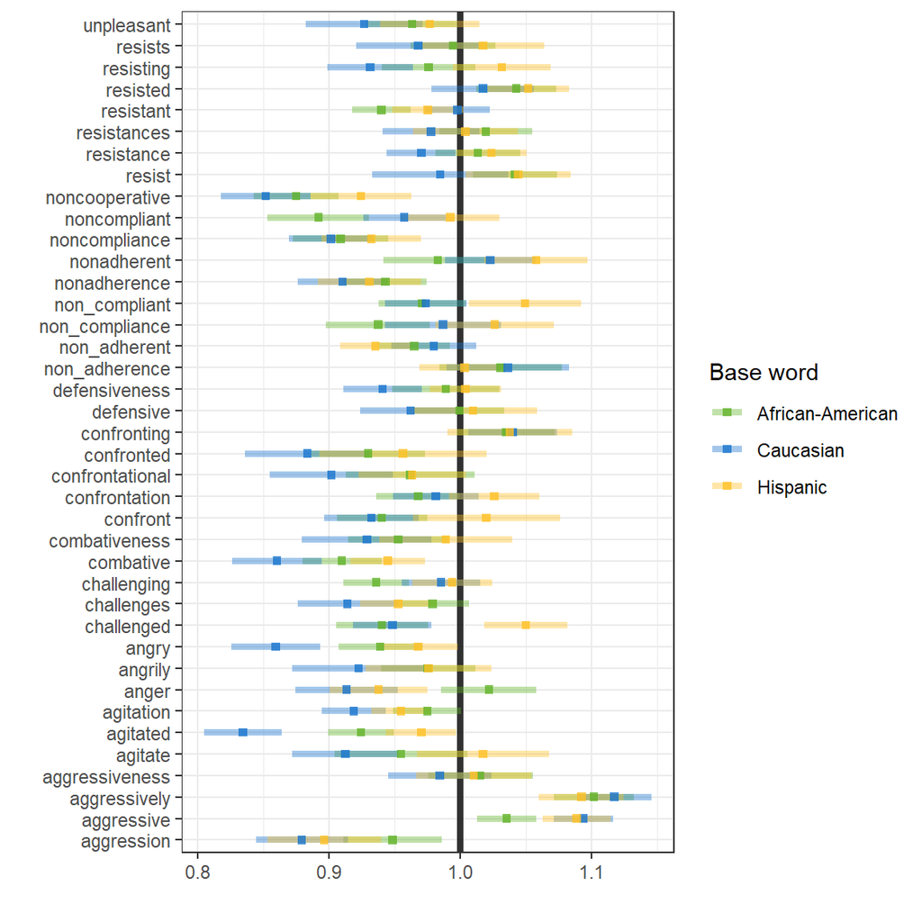

#### 4.1.2.2 Violence Subclass

#### 4.1.2.3 95% CI

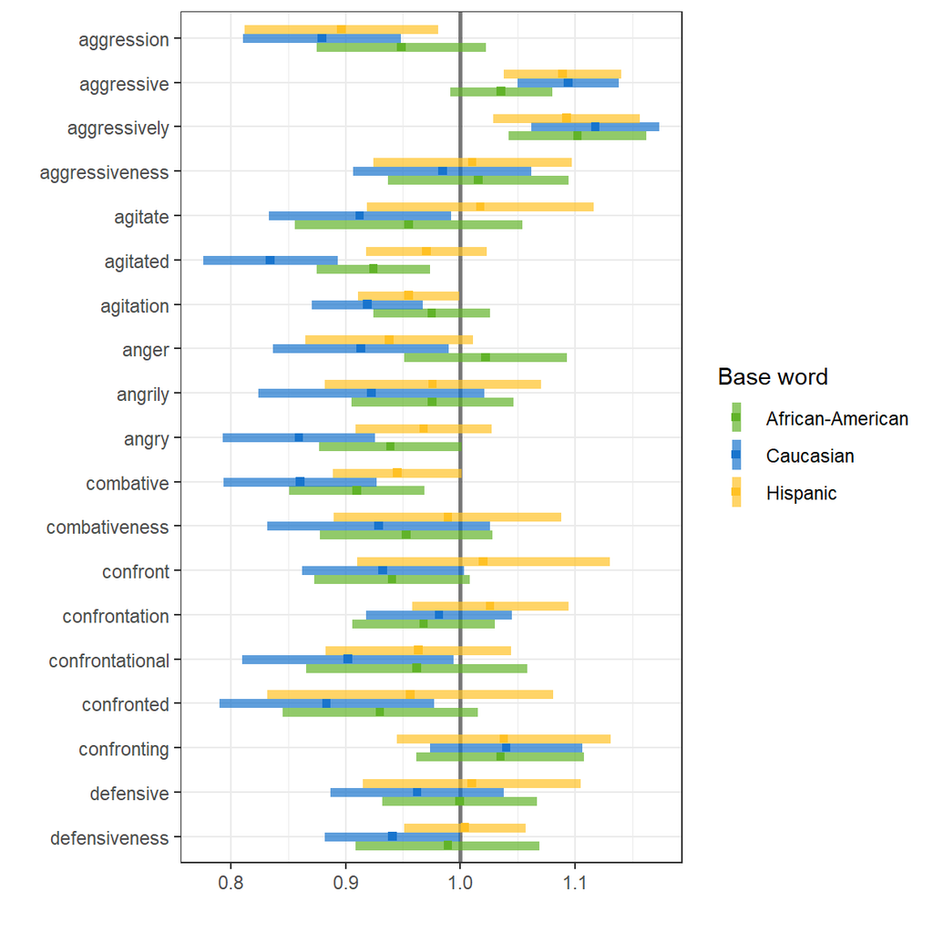

##### 4.1.2.3.1 SE Bars

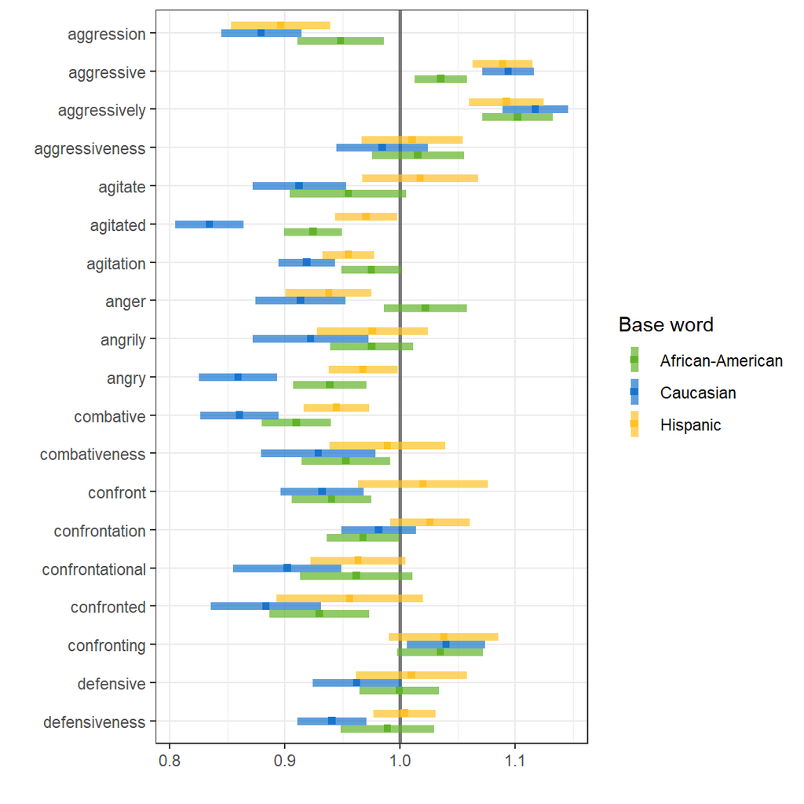

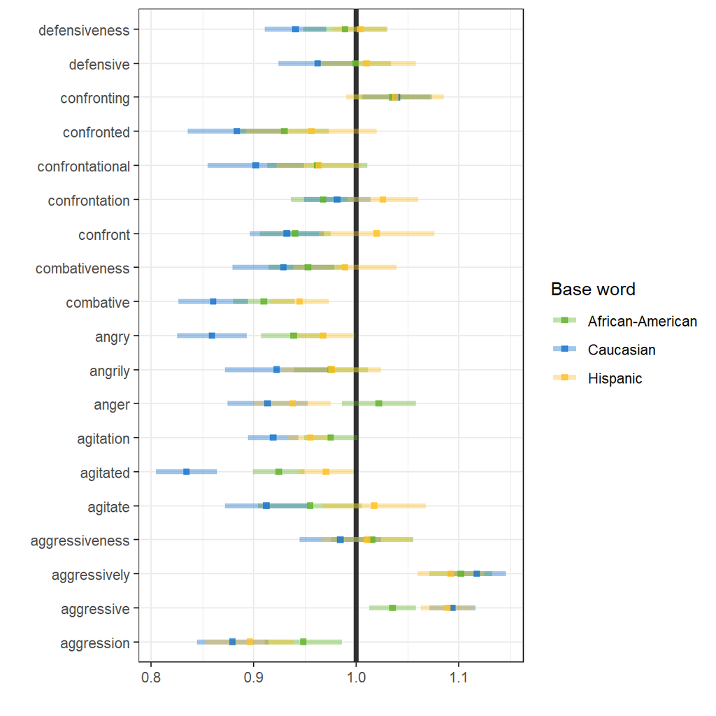

#### 4.1.2.4 Passivity Subclass

##### 4.1.2.4.1 SE Bars

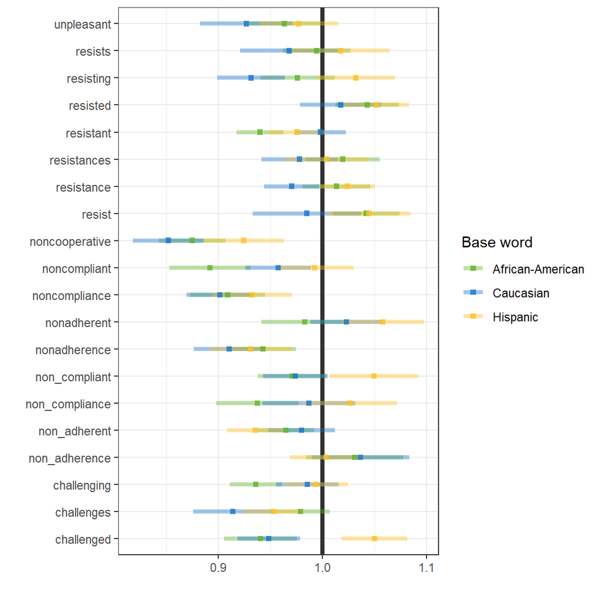

#### 4.1.2.5 “Non-adherence” Target Words

##### 4.1.2.5.1 SE Bars

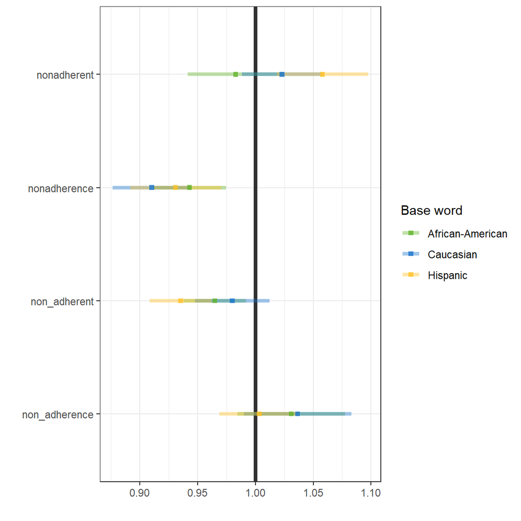

#### 4.1.2.6 “Non-compliance” Target Words

##### 4.1.2.6.1 SE Bars

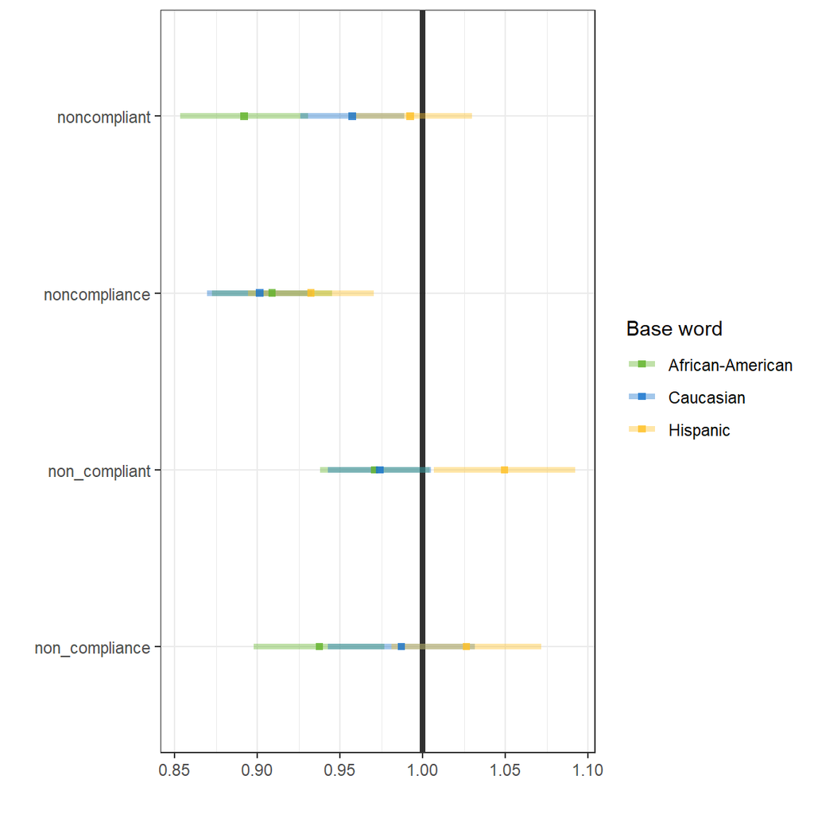

## 4.3 Three Bases and Single Target

These tests point out whether or not there is a difference between two groups, corrected for multiple testing.

### 4.3.1 Confidence Intervals

```r
two_sample_tests <- boot_data %>%

  group_by(target_word, bootstrap) %>%
  mutate(ac=african_american-caucasian) %>%
  mutate(ah=african_american-hispanic) %>%
  mutate(ch=caucasian-hispanic) %>%

  summarize(mean_ac=mean(ac),
            mean_ah=mean(ah),
            mean_ch=mean(ch)) %>%

  summarize(ci_ac=make_ci(mean_ac, ci_width=2.13, test_value=0),
            ci_ah=make_ci(mean_ah, ci_width=2.13, test_value=0),
            ci_ch=make_ci(mean_ch, ci_width=2.13, test_value=0))
```

| target_word | ci_ac | ci_ah | ci_ch |
| --- | --- | --- | --- |
| aggression | (-0.013, 0.151) | (-0.051, 0.155) | (-0.097, 0.064) |
| aggressive | (-0.111, -0.008)* | (-0.121, 0.013) | (-0.067, 0.078) |
| aggressively | (-0.085, 0.054) | (-0.075, 0.094) | (-0.065, 0.115) |
| aggressiveness | (-0.056, 0.119) | (-0.068, 0.078) | (-0.118, 0.065) |
| agitate | (-0.05, 0.136) | (-0.161, 0.036) | (-0.214, 0.004) |
| agitated | (0.013, 0.167)* | (-0.122, 0.029) | (-0.205, -0.066)* |
| agitation | (-0.014, 0.126) | (-0.053, 0.092) | (-0.104, 0.032) |
| anger | (0.029, 0.187)* | (-0.007, 0.174) | (-0.106, 0.057) |
| angrily | (-0.043, 0.149) | (-0.102, 0.101) | (-0.159, 0.051) |
| angry | (0.005, 0.154)* | (-0.109, 0.051) | (-0.183, -0.034)* |
| challenged | (-0.103, 0.087) | (-0.198, -0.022)* | (-0.193, -0.011)* |
| challenges | (-0.021, 0.151) | (-0.052, 0.105) | (-0.13, 0.052) |
| challenging | (-0.118, 0.02) | (-0.141, 0.025) | (-0.086, 0.068) |
| combative | (-0.03, 0.129) | (-0.112, 0.043) | (-0.171, 0.002) |
| combativeness | (-0.078, 0.126) | (-0.13, 0.058) | (-0.158, 0.038) |
| confront | (-0.09, 0.106) | (-0.234, 0.075) | (-0.233, 0.058) |
| confrontation | (-0.081, 0.054) | (-0.152, 0.036) | (-0.14, 0.051) |
| confrontational | (-0.046, 0.166) | (-0.103, 0.1) | (-0.167, 0.045) |
| confronted | (-0.043, 0.136) | (-0.127, 0.074) | (-0.174, 0.028) |
| confronting | (-0.086, 0.074) | (-0.102, 0.097) | (-0.069, 0.075) |
| defensive | (-0.04, 0.114) | (-0.115, 0.094) | (-0.145, 0.05) |
| defensiveness | (-0.031, 0.127) | (-0.089, 0.06) | (-0.092, -0.034)* |
| non_adherence | (-0.077, 0.066) | (-0.07, 0.124) | (-0.072, 0.137) |
| non_adherent | (-0.094, 0.065) | (-0.051, 0.11) | (-0.033, 0.123) |
| non_compliance | (-0.125, 0.026) | (-0.174, -0.004)* | (-0.122, 0.043) |
| non_compliant | (-0.081, 0.075) | (-0.178, 0.021) | (-0.165, 0.014) |
| nonadherence | (-0.051, 0.116) | (-0.09, 0.114) | (-0.124, 0.084) |
| nonadherent | (-0.136, 0.057) | (-0.164, 0.015) | (-0.133, 0.063) |
| noncompliance | (-0.088, 0.102) | (-0.112, 0.065) | (-0.124, 0.062) |
| noncompliant | (-0.145, 0.012) | (-0.204, 0.001) | (-0.128, 0.058) |
| noncooperative | (-0.054, 0.101) | (-0.15, 0.051) | (-0.155, 0.01) |
| resist | (-0.059, 0.172) | (-0.101, 0.096) | (-0.16, 0.042) |
| resistance | (-0.03, 0.116) | (-0.086, 0.064) | (-0.121, 0.013) |
| resistances | (-0.049, 0.133) | (-0.073, 0.105) | (-0.117, 0.065) |
| resistant | (-0.13, 0.013) | (-0.118, 0.047) | (-0.051, 0.097) |
| resisted | (-0.069, 0.12) | (-0.087, 0.068) | (-0.137, 0.068) |
| resisting | (-0.046, 0.135) | (-0.159, 0.047) | (-0.184, -0.017)* |
| resists | (-0.064, 0.117) | (-0.13, 0.084) | (-0.142, 0.043) |
| unpleasant | (-0.05, 0.123) | (-0.11, 0.083) | (-0.139, 0.038) |

### 4.3.2 Plots

#### 4.3.2.1 Stigmatizing Language

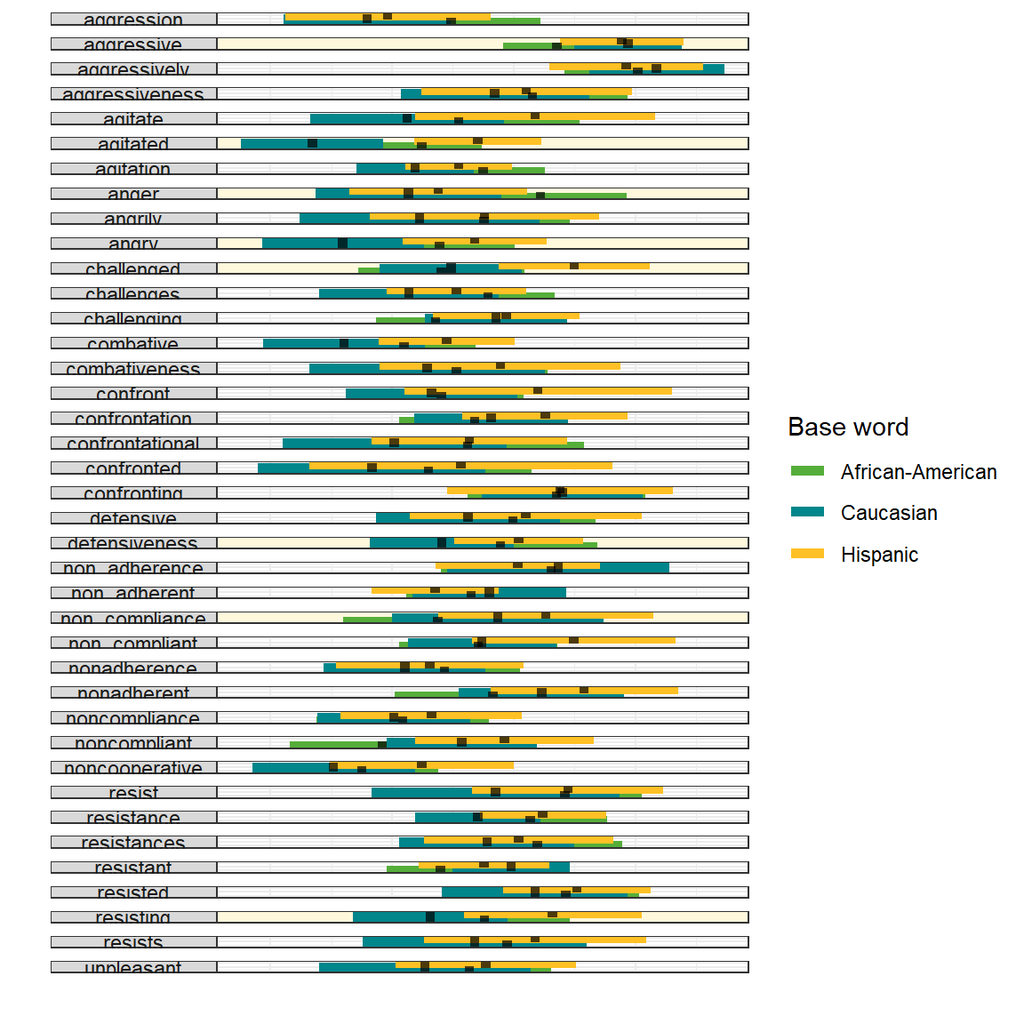

#### 4.3.2.2 Violence Subclass

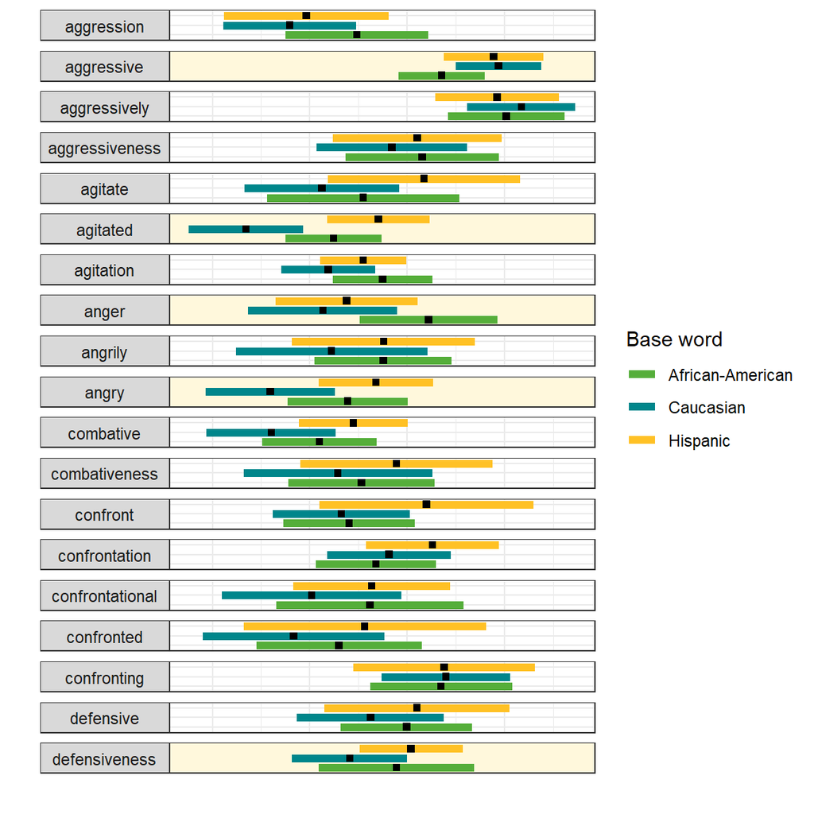

#### 4.3.2.3 Passivity Subclass

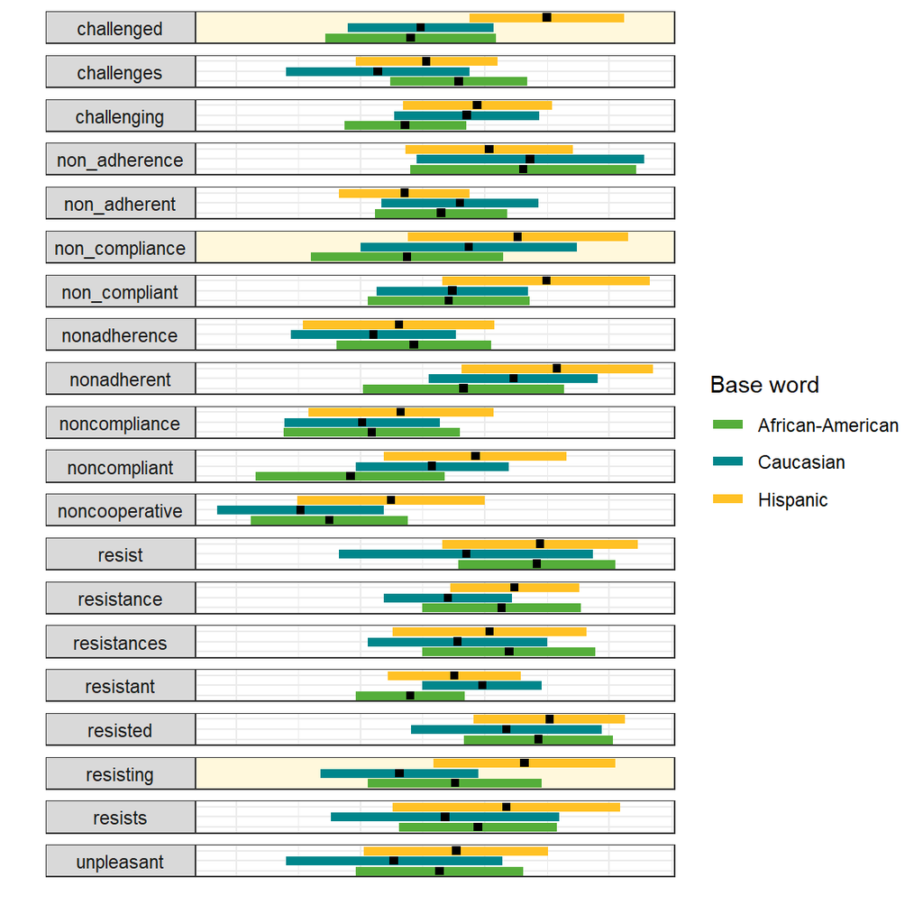

#### 4.3.2.4 “Non-adherence” Target Words

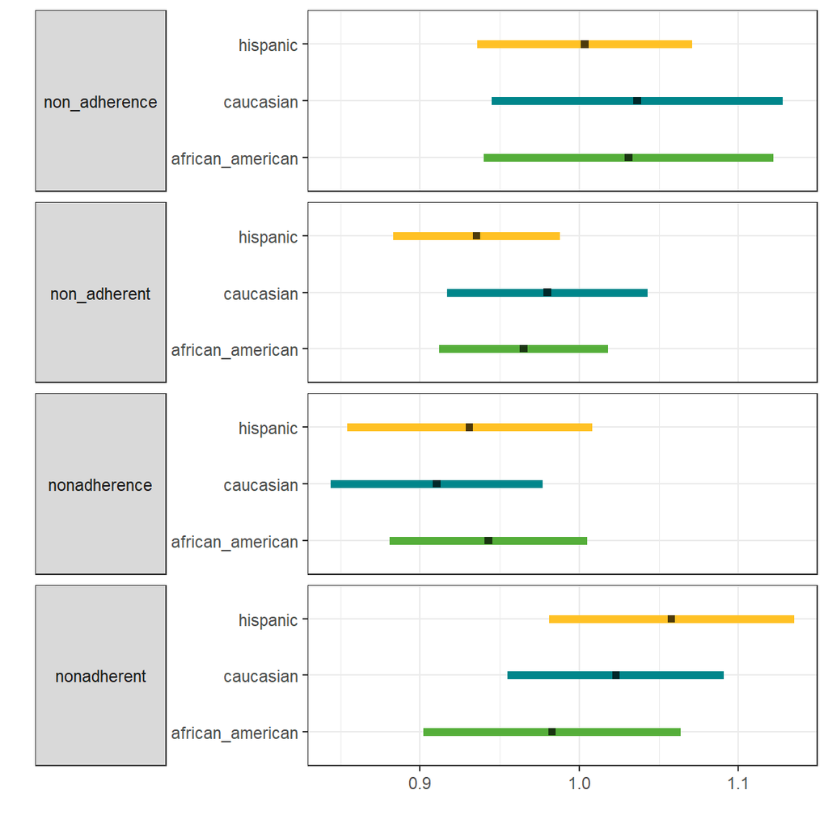

#### 4.3.2.5 “Non-compliance” Target Words

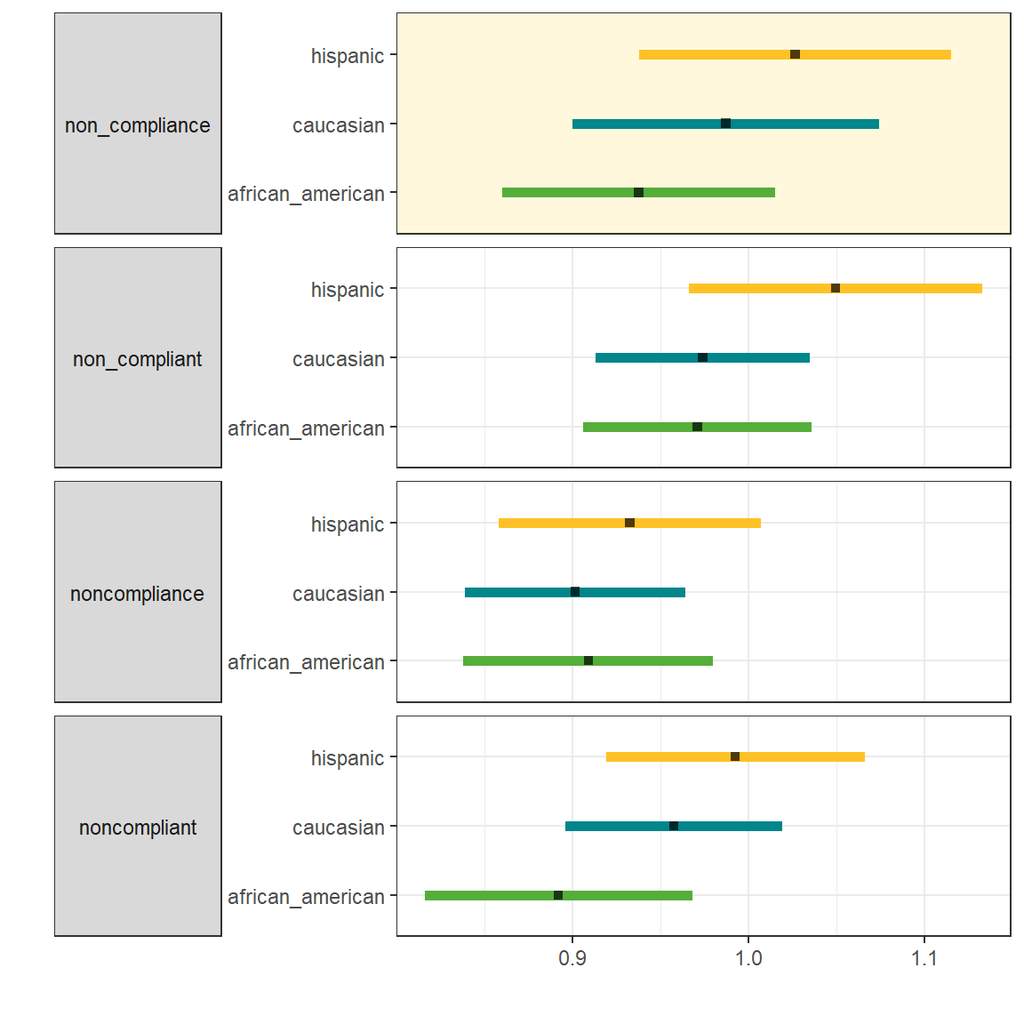

## 4.4 Three Bases and Synonymous/Class Targets

We will calculate the difference in mean precision-weighted averages for each base/base pair. Here is some pseudocode.

```
# create list to save all difference in precision-weighted averages
all_differences = []

# using each bootstrap dataset, calculate pwa difference
for bootstrap_m in all_bootstraps:
  for target_f in all_synonym_targets:
    # calculate mean, sd, ak
    mean_1, mean_2 = mean(cosine_distance_1), mean(cosine_distance_2)
    sd_1,   sd_2   = sd(cosine_distance_1), sd(cosine_distance_2)
    ak_1,   ak_2   = sd_1^-2, sd_2^-2

  # calculate precision-weighted averages
  pwa_1 = sum(ak_1 * mean_1) / sum(ak_1)
  pwa_2 = sum(ak_2 * mean_2) / sum(ak_2)
  difference_pwa = pwa_1 - pwa_2

# create confidence interval
mean(difference_pwa) - 2.13*sd(difference_pwa)
mean(difference_pwa) + 2.13*sd(difference_pwa)
```

### 4.4.1 Confidence Intervals

I am going to do the tests I showed above. These tests are Bonferroni corrected.

#### 4.4.1.1 Violence Subclass

##### 4.4.1.1.1 95% CI for PWA

```r
violence_pwa_test <- boot_data_long %>%
  filter(subclass == 'violence') %>%
  group_by(bootstrap, target_word, base_word) %>%

  summarize(cdk = mean(cosine_distance),
            sdk = sd(cosine_distance),
            ak  = 1/sdk^2) %>%
  ungroup() %>%
  group_by(bootstrap, base_word) %>%

  mutate(ak_cdk = cdk * ak) %>%
  summarize(theta_k = sum(ak_cdk, na.rm=TRUE) / sum(ak, na.rm=TRUE)) %>%

  ungroup() %>%
  reshape2::dcast(bootstrap ~ base_word, value.var='theta_k') %>%

  summarize_at(.vars=c('african_american', 'caucasian', 'hispanic'),
               .funs=make_ci)
```

| african_american | caucasian | hispanic |
| --- | --- | --- |
| (0.954, 0.996)* | (0.905, 0.961)* | (0.963, 1.02) |

##### 4.4.1.1.2 95% CI for PWA Differences

Using our precision-weighted averages, we can conclude the following about the “mean” cosine distance between these groups and all the “violence” target words combined:

- There is a significant difference between the African-American and Caucasian base words
- There is a significant difference between the Caucasian and Hispanic base words

| ci_ac | ci_ah | ci_ch |
| --- | --- | --- |
| (0.013, 0.072)* | (-0.049, 0.017) | (-0.092, -0.025)* |

##### 4.4.1.1.3 Violence 95% CI Plot

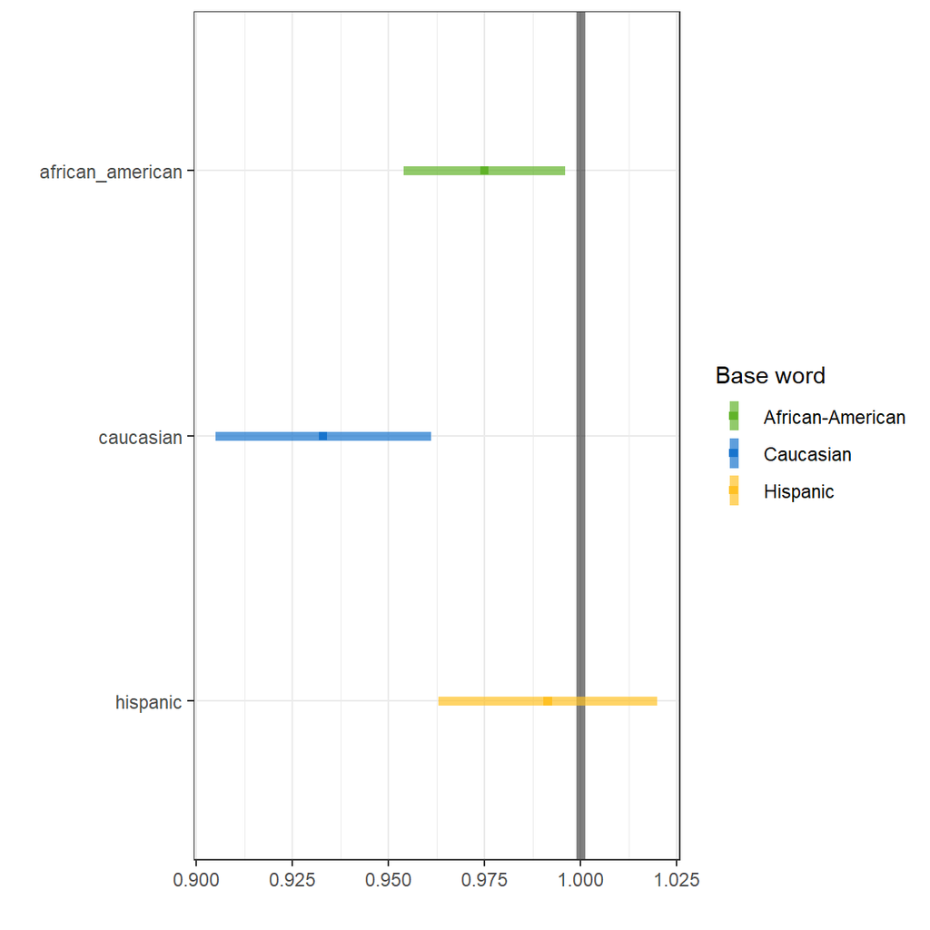

```r
# Get the 95% CI parameters
violence_pwa_test_plottable_0 <- boot_data_long %>%
  filter(subclass == 'violence') %>%
  group_by(bootstrap, target_word, base_word) %>%

  summarize(cdk = mean(cosine_distance),
            sdk = sd(cosine_distance),
            ak  = 1/sdk^2) %>%
  ungroup() %>%
  group_by(bootstrap, base_word) %>%

  mutate(ak_cdk = cdk * ak) %>%
  summarize(theta_k = sum(ak_cdk, na.rm=TRUE) / sum(ak, na.rm=TRUE)) %>%

  ungroup() %>%
  reshape2::dcast(bootstrap ~ base_word, value.var='theta_k') %>%

  summarize_at(.vars=c('african_american', 'caucasian', 'hispanic'),
               .funs=~make_ci(., print_format=FALSE)) %>%
  mutate(attr=rep(c('lb', 'ub', 'significance')))
# Reformat the data
violence_pwa_test_plottable <- violence_pwa_test_plottable_0 %>%
  reshape2::melt(id.vars=c('attr')) %>%
  rename(base_word=variable) %>%
  rename(pwa_average=value) %>%
  reshape2::dcast(base_word ~ attr, value.var='pwa_average') %>%
  mutate(avg = (lb + ub)/2) %>%
  mutate(se=(ub-avg)/1.96) %>%
  mutate(lb_se = avg - se) %>%
  mutate(ub_se = avg + se) %>%
  mutate(base_word=factor(base_word, levels=c('african_american', 'caucasian', 'hispanic')))

# Plot the data
violence_pwa_test_plottable %>%
    ggplot(aes( color = base_word)) +
      geom_hline(yintercept=1, lwd=2, alpha=0.5) +
    geom_linerange(aes(x = base_word, ymin = lb, ymax = ub),
                   size=2, alpha=0.7, position = position_dodge(width=0.6)) +
  geom_point(aes(x=base_word, y=avg),
             pch=15, position = position_dodge(width=0.6)) +

  scale_x_discrete(limits = rev) +
    coord_flip() +

    # Remove extraneous labels
    ylab('') +
    xlab('') +

    # Fix Legend
    scale_color_manual(name='Base word',
                       labels=c('African-American', 'Caucasian', 'Hispanic'),
                       values=c( '#61B329', '#1874CD',  '#FFC125')) +
    theme_bw()
```

#### 4.4.1.2 Passivity Subclass

##### 4.4.1.2.1 95% CI for PWA

```r
passivity_pwa_test <- boot_data_long %>%
  filter(subclass == 'passivity') %>%
  group_by(bootstrap, target_word, base_word) %>%

  summarize(cdk = mean(cosine_distance),
            sdk = sd(cosine_distance),
            ak  = 1/sdk^2) %>%
  ungroup() %>%
  group_by(bootstrap, base_word) %>%

  mutate(ak_cdk = cdk * ak) %>%
  summarize(theta_k = sum(ak_cdk, na.rm=TRUE) / sum(ak, na.rm=TRUE)) %>%

  ungroup() %>%
  reshape2::dcast(bootstrap ~ base_word, value.var='theta_k') %>%

  summarize_at(.vars=c('african_american', 'caucasian', 'hispanic'),
               .funs=make_ci)
```

| african_american | caucasian | hispanic |
| --- | --- | --- |
| (0.943, 0.988)* | (0.936, 0.986)* | (0.974, 1.022) |

##### 4.4.1.2.2 95% CI for PWA Differences

Using our precision-weighted averages, we can conclude the following about the “mean” cosine distance between these groups and all the “violence” target words combined:

- There is a significant difference between the Caucasian and Hispanic base words

| ci_ac | ci_ah | ci_ch |
| --- | --- | --- |
| (-0.032, 0.04) | (-0.067, 0.002) | (-0.073, 0)* |

##### 4.4.1.2.3 Passivity 95% CI Plot

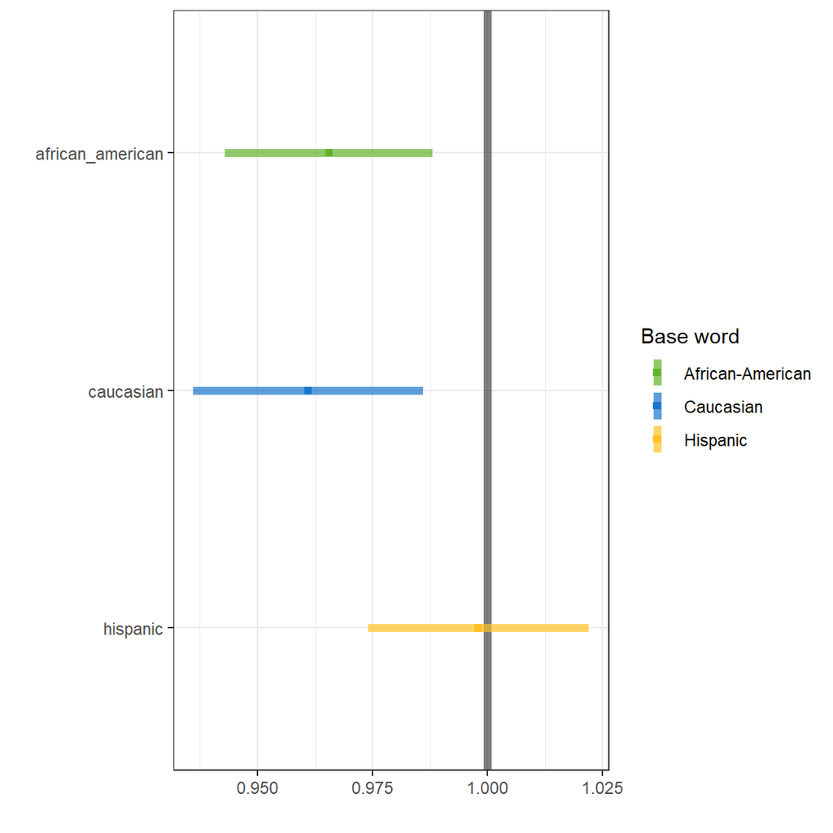

```r
# Get the 95% CI parameters
passivity_pwa_test_plottable_0 <- boot_data_long %>%
  filter(subclass == 'passivity') %>%
  group_by(bootstrap, target_word, base_word) %>%

  summarize(cdk = mean(cosine_distance),
            sdk = sd(cosine_distance),
            ak  = 1/sdk^2) %>%
  ungroup() %>%
  group_by(bootstrap, base_word) %>%

  mutate(ak_cdk = cdk * ak) %>%
  summarize(theta_k = sum(ak_cdk, na.rm=TRUE) / sum(ak, na.rm=TRUE)) %>%

  ungroup() %>%
  reshape2::dcast(bootstrap ~ base_word, value.var='theta_k') %>%

  summarize_at(.vars=c('african_american', 'caucasian', 'hispanic'),
               .funs=~make_ci(., print_format=FALSE)) %>%
  mutate(attr=rep(c('lb', 'ub', 'significance')))
# Reformat the data
passivity_pwa_test_plottable <- passivity_pwa_test_plottable_0 %>%
  reshape2::melt(id.vars=c('attr')) %>%
  rename(base_word=variable) %>%
  rename(pwa_average=value) %>%
  reshape2::dcast(base_word ~ attr, value.var='pwa_average') %>%
  mutate(avg = (lb + ub)/2) %>%
  mutate(se=(ub-avg)/1.96) %>%
  mutate(lb_se = avg - se) %>%
  mutate(ub_se = avg + se) %>%
  mutate(base_word=factor(base_word, levels=c('african_american', 'caucasian', 'hispanic')))

# Plot the data
passivity_pwa_test_plottable %>%
    ggplot(aes( color = base_word)) +
      geom_hline(yintercept=1, lwd=2, alpha=0.5) +
    geom_linerange(aes(x = base_word, ymin = lb, ymax = ub),
                   size=2, alpha=0.7, position = position_dodge(width=0.6)) +
  geom_point(aes(x=base_word, y=avg),
             pch=15, position = position_dodge(width=0.6)) +

  scale_x_discrete(limits = rev) +
    coord_flip() +

    # Remove extraneous labels
    ylab('') +
    xlab('') +

    # Fix Legend
    scale_color_manual(name='Base word',
                       labels=c('African-American', 'Caucasian', 'Hispanic'),
                       values=c( '#61B329', '#1874CD',  '#FFC125')) +
    theme_bw()
```

#### 4.4.1.3 “Non-adherence” Target Words

##### 4.4.1.3.1 95% CI for PWA

```r
adherence_pwa_test <- boot_data_long %>%
  filter(grepl('adher', target_word)) %>%
  group_by(bootstrap, target_word, base_word) %>%

  summarize(cdk = mean(cosine_distance),
            sdk = sd(cosine_distance),
            ak  = 1/sdk^2) %>%
  ungroup() %>%
  group_by(bootstrap, base_word) %>%

  mutate(ak_cdk = cdk * ak) %>%
  summarize(theta_k = sum(ak_cdk, na.rm=TRUE) / sum(ak, na.rm=TRUE)) %>%

  ungroup() %>%
  reshape2::dcast(bootstrap ~ base_word, value.var='theta_k') %>%

  summarize_at(.vars=c('african_american', 'caucasian', 'hispanic'),
               .funs=make_ci)
```

| african_american | caucasian | hispanic |
| --- | --- | --- |
| (0.939, 1.021) | (0.935, 1.032) | (0.927, 1.035) |

##### 4.4.1.3.2 95% CI for PWA Differences

Using our precision-weighted averages, we can conclude the following about the “mean” cosine distance between these groups and all the “non-adherence” target words combined:

- None

| ci_ac | ci_ah | ci_ch |
| --- | --- | --- |
| (-0.064, 0.058) | (-0.069, 0.067) | (-0.073, 0.078) |

##### 4.4.1.3.3 “Non-Adherence” 95% CI Plot

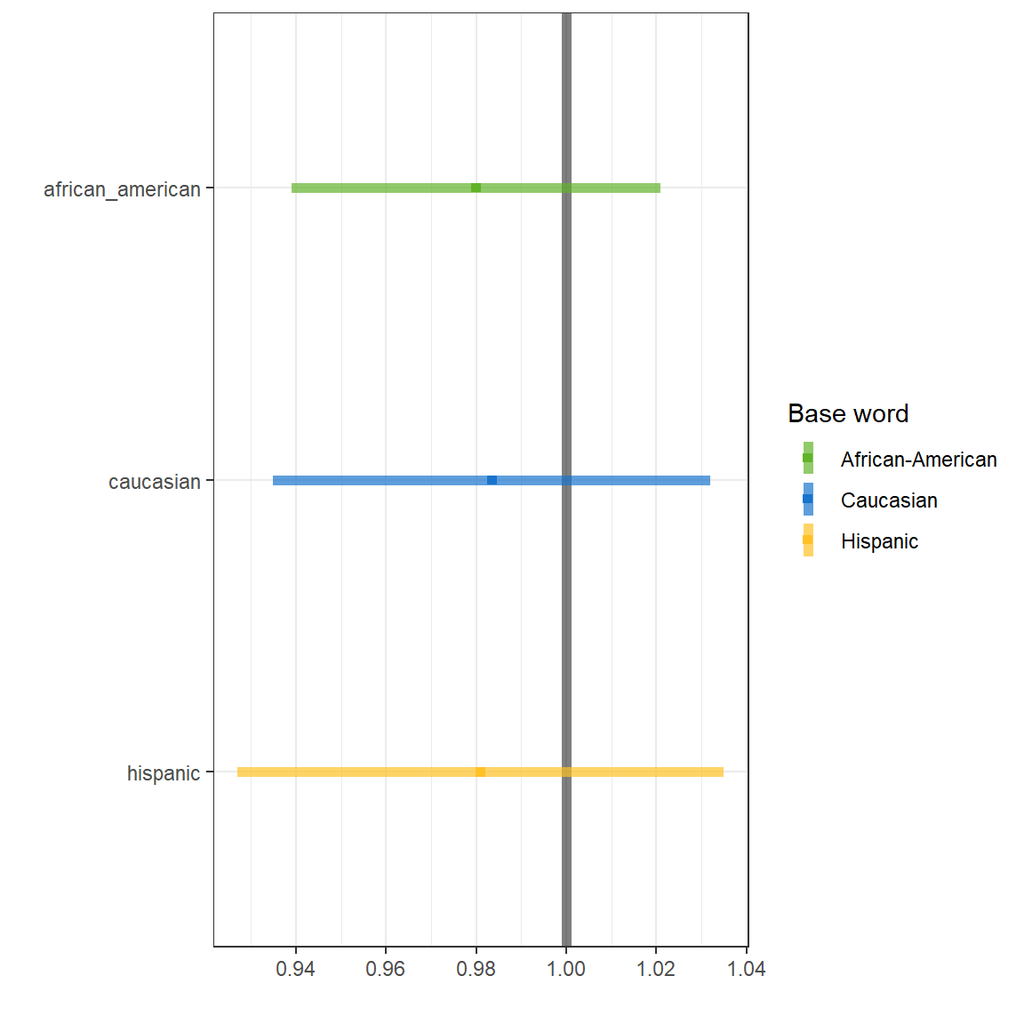

```r
# Get the 95% CI parameters
adher_pwa_test_plottable_0 <- boot_data_long %>%
  filter(grepl('adher', target_word)) %>%
  group_by(bootstrap, target_word, base_word) %>%

  summarize(cdk = mean(cosine_distance),
            sdk = sd(cosine_distance),
            ak  = 1/sdk^2) %>%
  ungroup() %>%
  group_by(bootstrap, base_word) %>%

  mutate(ak_cdk = cdk * ak) %>%
  summarize(theta_k = sum(ak_cdk, na.rm=TRUE) / sum(ak, na.rm=TRUE)) %>%

  ungroup() %>%
  reshape2::dcast(bootstrap ~ base_word, value.var='theta_k') %>%

  summarize_at(.vars=c('african_american', 'caucasian', 'hispanic'),
               .funs=~make_ci(., print_format=FALSE)) %>%
  mutate(attr=rep(c('lb', 'ub', 'significance')))
# Reformat the data
adher_pwa_test_plottable <- adher_pwa_test_plottable_0 %>%
  reshape2::melt(id.vars=c('attr')) %>%
  rename(base_word=variable) %>%
  rename(pwa_average=value) %>%
  reshape2::dcast(base_word ~ attr, value.var='pwa_average') %>%
  mutate(avg = (lb + ub)/2) %>%
  mutate(se=(ub-avg)/1.96) %>%
  mutate(lb_se = avg - se) %>%
  mutate(ub_se = avg + se) %>%
  mutate(base_word=factor(base_word, levels=c('african_american', 'caucasian', 'hispanic')))

# Plot the data
adher_pwa_test_plottable %>%
    ggplot(aes( color = base_word)) +
      geom_hline(yintercept=1, lwd=2, alpha=0.5) +
    geom_linerange(aes(x = base_word, ymin = lb, ymax = ub),
                   size=2, alpha=0.7, position = position_dodge(width=0.6)) +
  geom_point(aes(x=base_word, y=avg),
             pch=15, position = position_dodge(width=0.6)) +

  scale_x_discrete(limits = rev) +
    coord_flip() +

    # Remove extraneous labels
    ylab('') +
    xlab('') +

    # Fix Legend
    scale_color_manual(name='Base word',
                       labels=c('African-American', 'Caucasian', 'Hispanic'),
                       values=c( '#61B329', '#1874CD',  '#FFC125')) +
    theme_bw()
```

#### 4.4.1.4 “Non-compliance” Target Words

##### 4.4.1.4.1 95% CI for PWA

```r
compliance_pwa_test <- boot_data_long %>%
  filter(grepl('compli', target_word)) %>%
  group_by(bootstrap, target_word, base_word) %>%

  summarize(cdk = mean(cosine_distance),
            sdk = sd(cosine_distance),
            ak  = 1/sdk^2) %>%
  ungroup() %>%
  group_by(bootstrap, base_word) %>%

  mutate(ak_cdk = cdk * ak) %>%
  summarize(theta_k = sum(ak_cdk, na.rm=TRUE) / sum(ak, na.rm=TRUE)) %>%

  ungroup() %>%
  reshape2::dcast(bootstrap ~ base_word, value.var='theta_k') %>%

  summarize_at(.vars=c('african_american', 'caucasian', 'hispanic'),
               .funs=make_ci)
```

| african_american | caucasian | hispanic |
| --- | --- | --- |
| (0.872, 0.971)* | (0.906, 0.997)* | (0.943, 1.051) |

##### 4.4.1.4.2 95% CI for PWA Differences

Using our precision-weighted averages, we can conclude the following about the “mean” cosine distance between these groups and all the “non-compliance” target words combined:

- There is a significant difference between the African-American and Hispanic base words

| ci_ac | ci_ah | ci_ch |
| --- | --- | --- |
| (-0.091, 0.032) | (-0.139, -0.011)* | (-0.115, 0.024) |

##### 4.4.1.4.3 “Non-Compliance” 95% CI Plot

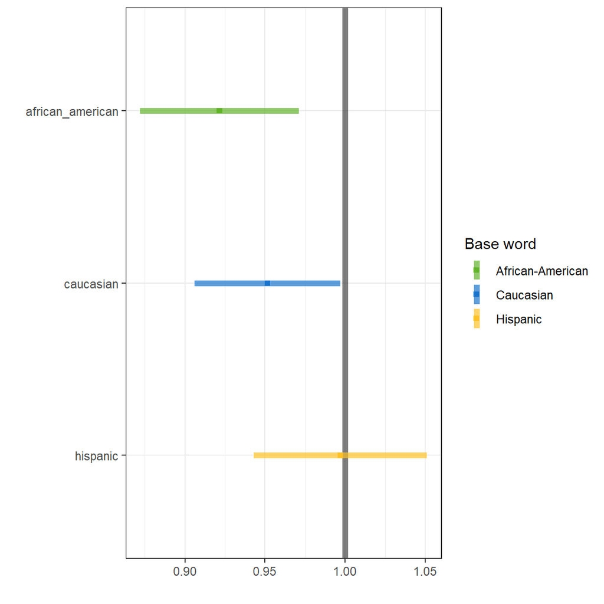

```r
# Get the 95% CI parameters
compli_pwa_test_plottable_0 <- boot_data_long %>%
  filter(grepl('compli', target_word)) %>%
  group_by(bootstrap, target_word, base_word) %>%

  summarize(cdk = mean(cosine_distance),
            sdk = sd(cosine_distance),
            ak  = 1/sdk^2) %>%
  ungroup() %>%
  group_by(bootstrap, base_word) %>%

  mutate(ak_cdk = cdk * ak) %>%
  summarize(theta_k = sum(ak_cdk, na.rm=TRUE) / sum(ak, na.rm=TRUE)) %>%

  ungroup() %>%
  reshape2::dcast(bootstrap ~ base_word, value.var='theta_k') %>%

  summarize_at(.vars=c('african_american', 'caucasian', 'hispanic'),
               .funs=~make_ci(., print_format=FALSE)) %>%
  mutate(attr=rep(c('lb', 'ub', 'significance')))
# Reformat the data
compli_pwa_test_plottable <- compli_pwa_test_plottable_0 %>%
  reshape2::melt(id.vars=c('attr')) %>%
  rename(base_word=variable) %>%
  rename(pwa_average=value) %>%
  reshape2::dcast(base_word ~ attr, value.var='pwa_average') %>%
  mutate(avg = (lb + ub)/2) %>%
  mutate(se=(ub-avg)/1.96) %>%
  mutate(lb_se = avg - se) %>%
  mutate(ub_se = avg + se) %>%
  mutate(base_word=factor(base_word, levels=c('african_american', 'caucasian', 'hispanic')))

# Plot the data
compli_pwa_test_plottable %>%
    ggplot(aes( color = base_word)) +
      geom_hline(yintercept=1, lwd=2, alpha=0.5) +
    geom_linerange(aes(x = base_word, ymin = lb, ymax = ub),
                   size=2, alpha=0.7, position = position_dodge(width=0.6)) +
  geom_point(aes(x=base_word, y=avg),
             pch=15, position = position_dodge(width=0.6)) +

  scale_x_discrete(limits = rev) +
    coord_flip() +

    # Remove extraneous labels
    ylab('') +
    xlab('') +

    # Fix Legend
    scale_color_manual(name='Base word',
                       labels=c('African-American', 'Caucasian', 'Hispanic'),
                       values=c( '#61B329', '#1874CD',  '#FFC125')) +
    theme_bw()
```

#### 4.4.1.5 “Non-compliance” and “Non-adherence” Target Words

##### 4.4.1.5.1 95% CI for PWA

```r
compadher_pwa_test <- boot_data_long %>%
  filter(grepl('compli|adher', target_word)) %>%
  group_by(bootstrap, target_word, base_word) %>%

  summarize(cdk = mean(cosine_distance),
            sdk = sd(cosine_distance),
            ak  = 1/sdk^2) %>%
  ungroup() %>%
  group_by(bootstrap, base_word) %>%

  mutate(ak_cdk = cdk * ak) %>%
  summarize(theta_k = sum(ak_cdk, na.rm=TRUE) / sum(ak, na.rm=TRUE)) %>%

  ungroup() %>%
  reshape2::dcast(bootstrap ~ base_word, value.var='theta_k') %>%

  summarize_at(.vars=c('african_american', 'caucasian', 'hispanic'),
               .funs=make_ci)
```

| african_american | caucasian | hispanic |
| --- | --- | --- |
| (0.913, 0.987)* | (0.931, 1.003) | (0.943, 1.034) |

##### 4.4.1.5.2 95% CI for PWA Differences

Using our precision-weighted averages, we can conclude the following about the “mean” cosine distance between these groups and all the “non-compliance” target words combined:

- No differences

| ci_ac | ci_ah | ci_ch |
| --- | --- | --- |
| (-0.069, 0.035) | (-0.096, 0.019) | (-0.083, 0.04) |

##### 4.4.1.5.3 Compliance/Adherence 95% CI Plot

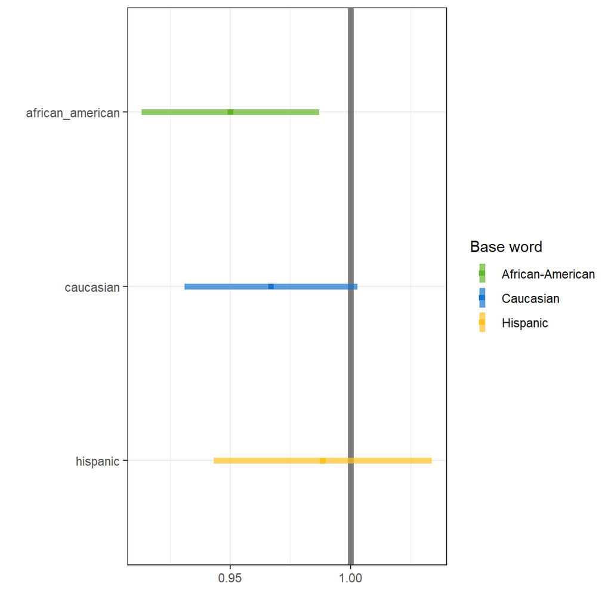

```r
# Get the 95% CI parameters
compadher_pwa_test_plottable_0 <- boot_data_long %>%
  filter(grepl('compli|adher', target_word)) %>%
  group_by(bootstrap, target_word, base_word) %>%

  summarize(cdk = mean(cosine_distance),
            sdk = sd(cosine_distance),
            ak  = 1/sdk^2) %>%
  ungroup() %>%
  group_by(bootstrap, base_word) %>%

  mutate(ak_cdk = cdk * ak) %>%
  summarize(theta_k = sum(ak_cdk, na.rm=TRUE) / sum(ak, na.rm=TRUE)) %>%

  ungroup() %>%
  reshape2::dcast(bootstrap ~ base_word, value.var='theta_k') %>%

  summarize_at(.vars=c('african_american', 'caucasian', 'hispanic'),
               .funs=~make_ci(., print_format=FALSE)) %>%
  mutate(attr=rep(c('lb', 'ub', 'significance')))
# Reformat the data
compadher_pwa_test_plottable <- compadher_pwa_test_plottable_0 %>%
  reshape2::melt(id.vars=c('attr')) %>%
  rename(base_word=variable) %>%
  rename(pwa_average=value) %>%
  reshape2::dcast(base_word ~ attr, value.var='pwa_average') %>%
  mutate(avg = (lb + ub)/2) %>%
  mutate(se=(ub-avg)/1.96) %>%
  mutate(lb_se = avg - se) %>%
  mutate(ub_se = avg + se) %>%
  mutate(base_word=factor(base_word, levels=c('african_american', 'caucasian', 'hispanic')))

# Plot the data
compadher_pwa_test_plottable %>%
    ggplot(aes( color = base_word)) +
      geom_hline(yintercept=1, lwd=2, alpha=0.5) +
    geom_linerange(aes(x = base_word, ymin = lb, ymax = ub),
                   size=2, alpha=0.7, position = position_dodge(width=0.6)) +
  geom_point(aes(x=base_word, y=avg),
             pch=15, position = position_dodge(width=0.6)) +

  scale_x_discrete(limits = rev) +
    coord_flip() +

    # Remove extraneous labels
    ylab('') +
    xlab('') +

    # Fix Legend
    scale_color_manual(name='Base word',
                       labels=c('African-American', 'Caucasian', 'Hispanic'),
                       values=c( '#61B329', '#1874CD',  '#FFC125')) +
    theme_bw()
```

#### 4.4.1.6 Words that can describe patient

- Non-cooperative
- All of the adherence terms
- All non-compliance terms -Anger, angrily
- Combative
- Confront
- Unpleasant
- Agitation

```r
adjectives_for_patients <- c('noncooperative', 'nonadherent', 'non_adherence', 'non_adherent', 'nonadherence', 'noncompliance', 'non_compliant', 'non_compliance', 'noncompliant', 'anger', 'angrily', 'combative', 'confront', 'unpleasant', 'agitation')
```

##### 4.4.1.6.1 95% CI for PWA

```r
patients_pwa_test <- boot_data_long %>%
  filter(target_word %in% adjectives_for_patients) %>%
  group_by(bootstrap, target_word, base_word) %>%

  summarize(cdk = mean(cosine_distance),
            sdk = sd(cosine_distance),
            ak  = 1/sdk^2) %>%
  ungroup() %>%
  group_by(bootstrap, base_word) %>%

  mutate(ak_cdk = cdk * ak) %>%
  summarize(theta_k = sum(ak_cdk, na.rm=TRUE) / sum(ak, na.rm=TRUE)) %>%

  ungroup() %>%
  reshape2::dcast(bootstrap ~ base_word, value.var='theta_k') %>%

  summarize_at(.vars=c('african_american', 'caucasian', 'hispanic'),
               .funs=make_ci)
```

| african_american | caucasian | hispanic |
| --- | --- | --- |
| (0.925, 0.979)* | (0.909, 0.966)* | (0.94, 1.01) |

##### 4.4.1.6.2 95% CI for PWA Differences

Using our precision-weighted averages, we can conclude the following about the “mean” cosine distance between these groups and all the “non-compliance” target words combined:

- No differences

| ci_ac | ci_ah | ci_ch |
| --- | --- | --- |
| (-0.021, 0.048) | (-0.07, 0.024) | (-0.082, 0.009) |

##### 4.4.1.6.3 Adjectives for Patients 95% CI Plot

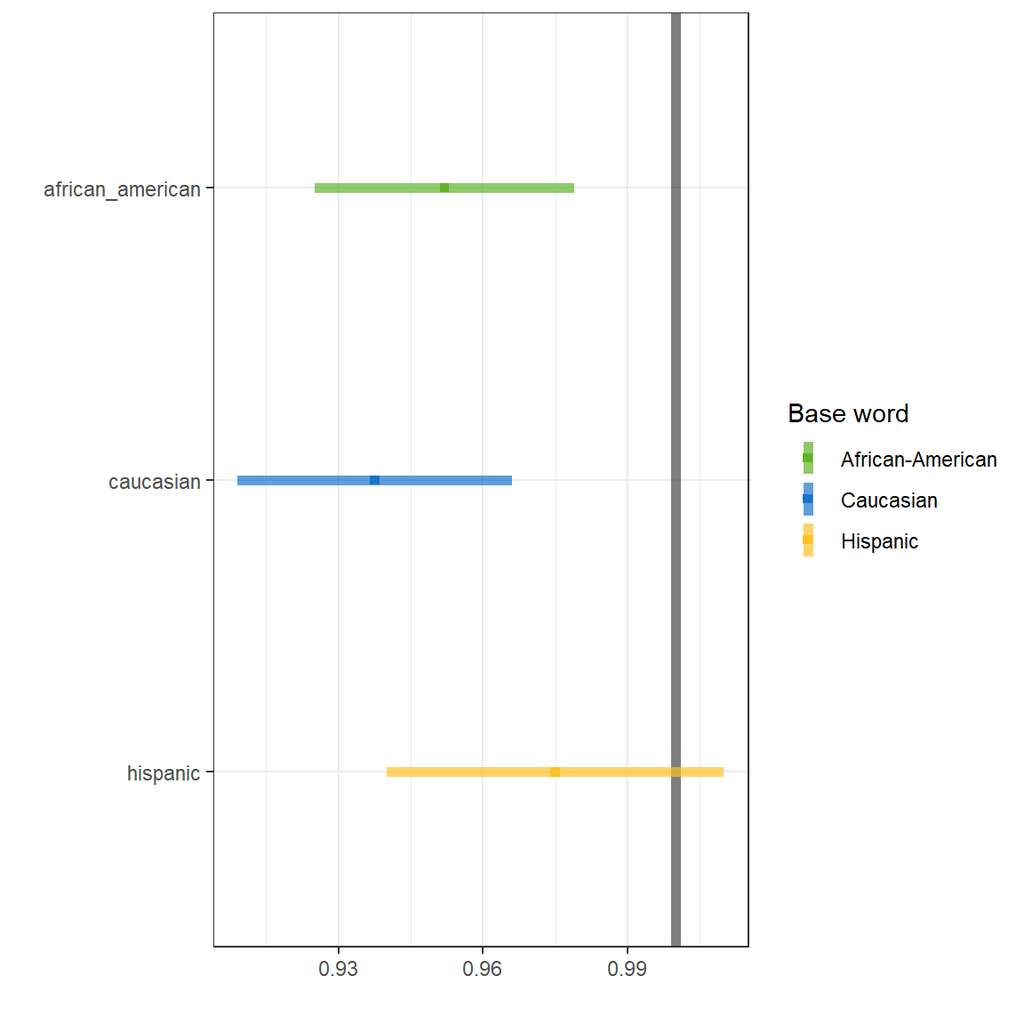

```r
# Get the 95% CI parameters
adjec_pwa_test_plottable_0 <- boot_data_long %>%
  filter(target_word %in% adjectives_for_patients) %>%
  group_by(bootstrap, target_word, base_word) %>%

  summarize(cdk = mean(cosine_distance),
            sdk = sd(cosine_distance),
            ak  = 1/sdk^2) %>%
  ungroup() %>%
  group_by(bootstrap, base_word) %>%

  mutate(ak_cdk = cdk * ak) %>%
  summarize(theta_k = sum(ak_cdk, na.rm=TRUE) / sum(ak, na.rm=TRUE)) %>%

  ungroup() %>%
  reshape2::dcast(bootstrap ~ base_word, value.var='theta_k') %>%

  summarize_at(.vars=c('african_american', 'caucasian', 'hispanic'),
               .funs=~make_ci(., print_format=FALSE)) %>%
  mutate(attr=rep(c('lb', 'ub', 'significance')))
# Reformat the data
adjec_pwa_test_plottable <- adjec_pwa_test_plottable_0 %>%
  reshape2::melt(id.vars=c('attr')) %>%
  rename(base_word=variable) %>%
  rename(pwa_average=value) %>%
  reshape2::dcast(base_word ~ attr, value.var='pwa_average') %>%
  mutate(avg = (lb + ub)/2) %>%
  mutate(se=(ub-avg)/1.96) %>%
  mutate(lb_se = avg - se) %>%
  mutate(ub_se = avg + se) %>%
  mutate(base_word=factor(base_word, levels=c('african_american', 'caucasian', 'hispanic')))

# Plot the data
adjec_pwa_test_plottable %>%
    ggplot(aes( color = base_word)) +
      geom_hline(yintercept=1, lwd=2, alpha=0.5) +
    geom_linerange(aes(x = base_word, ymin = lb, ymax = ub),
                   size=2, alpha=0.7, position = position_dodge(width=0.6)) +
  geom_point(aes(x=base_word, y=avg),
             pch=15, position = position_dodge(width=0.6)) +

  scale_x_discrete(limits = rev) +
    coord_flip() +

    # Remove extraneous labels
    ylab('') +
    xlab('') +

    # Fix Legend
    scale_color_manual(name='Base word',
                       labels=c('African-American', 'Caucasian', 'Hispanic'),
                       values=c( '#61B329', '#1874CD',  '#FFC125')) +
    theme_bw()
```